# Project - Using GPs in the form of SDE in the localization of a drone based on UWB ranging measurements

## Classic Model

The model emplyed to describe and localize the drone is the constant acceleration model goven by $$ \dot{x} = {F} x + w $$ where $x=\begin{bmatrix}x_1&x_2&x_3 \end{bmatrix}^\top\in \mathbb{R^n}$ is the state aumented with its first two derivatives, ${F}\in\mathbb{R^{n\times n}}$ is the state transition matrix, and $w\in\mathbb{R^{m}}$ is a white noise process distributed as $\mathcal{N}({0}; \Sigma\in\mathbb{R^{m\times m}})$. $$ {F} = \begin{bmatrix} 0 & 1 & 0\\ 0 & 0 & 1\\ 0 & 0 & 0 \end{bmatrix} $$ with the analytical discrete-time state transition and state covariance matrices $$ {F_k} = \begin{bmatrix} 1 & \Delta t & \frac{1}{2}\Delta t^2\\ 0 & 1 & \Delta t\\ 0 & 0 & 1 \end{bmatrix},\;\;\; {\Sigma_k} = q\begin{bmatrix} \frac{\Delta t^5}{20}&\frac{\Delta t^4}{8}&\frac{\Delta t^3}{6}\\ \frac{\Delta t^4}{8}&\frac{\Delta t^3}{3}&\frac{\Delta t^2}{2}\\ \frac{\Delta t^3}{6}&\frac{\Delta t^2}{2}& \Delta t \end{bmatrix} $$

In the linear case, the usual measuremnts model is expressed as $$ y = H x $$ where $y\in\mathbb{R}$ is the measurement for $x_1$ and $H = \begin{bmatrix}1&0&0 \end{bmatrix}$. However, a nonlinear measuremnt model is used in this project. Further, multiple measuremnts are also to be used to ensure the observability and the uniqueness of solution for this prototypical range measurement-based localization problem. The general form for the $N$ range measurements is given below.

$$ h(x,x_{landmark}) = \begin{bmatrix} ||x-x_{landmark}^1||\\\\ ||x-x_{landmark}^2||\\\\ \vdots\\\\ ||x-x_{landmark}^N||\\\\ \end{bmatrix} $$

the jacobian matrix $H\in\mathbb{R}^{N\times 3}$ from the linearization of the above measurements function is given by

$$ H(x,x_{landmark}) = \begin{bmatrix} \nabla_x h(x,x_{landmark}^1\\\\ \vdots\\\\ \nabla_x h(x,x_{landmark}^N\\\\ \end{bmatrix} = \begin{bmatrix} \frac {x-x_{landmark}^1}{||x-x_{landmark}^1||} \\\\ \vdots\\\\ \frac {x-x_{landmark}^N}{||x-x_{landmark}^N||}\\\\ \end{bmatrix} $$

The jacobian is updated at every time step where measurements are available.

## LTI SDE GP Model

The Linear Time Invariant (LTI) Stochastic Differential Equation (SDE) model being considered as a substitute to the constant-acceleration tracking model usually deployed in this kind of scenario is given by:

$$ \dot{x} = {F} x + {L} w $$

where $x=\begin{bmatrix}x_1&x_2&x_3 \end{bmatrix}^\top\in \mathbb{R^n}$ is the state aumented with its first two derivatives, ${F}\in\mathbb{R^{n\times n}}$ is the state transition matrix, ${L\in\mathbb{R^{n\times m}}}$ is a constant matrix, and $w\in\mathbb{R^{m}}$ is a white noise process of zero mean and some spectral density $Q\in\mathbb{R^{m\times m}}$.

The above model can be adapted to describe approcimately or exactly certain Gaussian process covariance functions. The half-integer Matern kernel is one such example where the covariance can be written as a product of an exponential and a polynomial of degree $p$. The half-integer, $\nu$ Matern covariance function can be exactly described by the following model for $\nu = p + \frac{1}{2} = \frac{5}{2}$ where the polynomial is of degree $2$

$$ {F} = \begin{bmatrix} 0 & 1 & 0\\ 0 & 0 & 1\\ -\lambda^2 & -3\lambda^2 & -3\lambda \end{bmatrix} , \;\; {L} = \begin{bmatrix} 0\\0\\1 \end{bmatrix} $$

where $\lambda = \sqrt{2\nu}/l = \sqrt{5}/l$ for the Matern kernel covariance function with length scale $l$. The SDE is also charachterized under the Matern kernel by the following diffusion coeffient describing the noise process: $$ q = \sigma^2 \frac{[(D-1)!]^2}{(2D-2)!} ((2\lambda)^{2D-1}) $$ where $\sigma$ is the amplitude coefficient of the Matern function.

The measurements model is the exact one presented in the classic model section

To perform inference, a Kalman Filter-based (KF) framework is used employing the LTI SDE model and the nonlinear varying measurements model. So, technically, the Extended Kalman Filter (EKF) is to be used to estimate the state of the whole system based soley on the range measuremnts available to the drone at any given point in time.

To use the discrete EKF, the discrete state transition matrix ${F}$ and the discrete model noise covariance function from the above modelare required. This can be done via the following: $$ {F}_k = \exp({F}\Delta t)\\ {\Sigma_k} = \int_0^{\Delta t} \exp({F}(\Delta t_k - \tau)) L Q L^\top \exp({F}(\Delta t_k - \tau))^\top d\tau $$ where $\exp(\cdot)$ is the matric exponential. The above equations can sometimes be analytically solved, but it is often difficult espicially for the covariance. If the system is nilpotent of some degree, the calculations generally become easier. A simplification computed after truncating higher order terms can be given by:

$$ {F}_k =\left(\begin{array}{ccc} {\mathrm{e}}^{-\mathrm{dt}\,l}+\frac{{\mathrm{dt}}^2\,l^2\,{\mathrm{e}}^{-\mathrm{dt}\,l}}{2}+\mathrm{dt}\,l\,{\mathrm{e}}^{-\mathrm{dt}\,l} & \mathrm{dt}\,{\mathrm{e}}^{-\mathrm{dt}\,l}+{\mathrm{dt}}^2\,l\,{\mathrm{e}}^{-\mathrm{dt}\,l} & \frac{{\mathrm{dt}}^2\,{\mathrm{e}}^{-\mathrm{dt}\,l}}{2}\\ -\frac{{\mathrm{dt}}^2\,l^3\,{\mathrm{e}}^{-\mathrm{dt}\,l}}{2} & {\mathrm{e}}^{-\mathrm{dt}\,l}\,\left(-{\mathrm{dt}}^2\,l^2+\mathrm{dt}\,l+1\right) & -\frac{\mathrm{dt}\,{\mathrm{e}}^{-\mathrm{dt}\,l}\,\left(\mathrm{dt}\,l-2\right)}{2}\\ \frac{{\mathrm{dt}}^2\,l^4\,{\mathrm{e}}^{-\mathrm{dt}\,l}}{2}-\mathrm{dt}\,l^3\,{\mathrm{e}}^{-\mathrm{dt}\,l} & {\mathrm{dt}}^2\,l^3\,{\mathrm{e}}^{-\mathrm{dt}\,l}-3\,\mathrm{dt}\,l^2\,{\mathrm{e}}^{-\mathrm{dt}\,l} & {\mathrm{e}}^{-\mathrm{dt}\,l}+\frac{{\mathrm{dt}}^2\,l^2\,{\mathrm{e}}^{-\mathrm{dt}\,l}}{2}-2\,\mathrm{dt}\,l\,{\mathrm{e}}^{-\mathrm{dt}\,l} \end{array}\right) $$$$ {\Sigma_k} =\left(\begin{array}{ccc} \frac{3\,q}{16\,l^5}-\frac{q\,{\mathrm{e}}^{-2\,\mathrm{dt}\,l}\,\left(16\,{\mathrm{dt}}^4\,l^4+32\,{\mathrm{dt}}^3\,l^3+48\,{\mathrm{dt}}^2\,l^2+48\,\mathrm{dt}\,l+24\right)}{128\,l^5} & \frac{{\mathrm{dt}}^4\,q\,{\mathrm{e}}^{-2\,\mathrm{dt}\,l}}{8} & \frac{q\,{\mathrm{e}}^{-2\,\mathrm{dt}\,l}\,\left(2\,\mathrm{dt}\,l-{\mathrm{e}}^{2\,\mathrm{dt}\,l}+2\,{\mathrm{dt}}^2\,l^2+4\,{\mathrm{dt}}^3\,l^3-2\,{\mathrm{dt}}^4\,l^4+1\right)}{16\,l^3}\\ \frac{{\mathrm{dt}}^4\,q\,{\mathrm{e}}^{-2\,\mathrm{dt}\,l}}{8} & \frac{q}{16\,l^3}-\frac{q\,{\mathrm{e}}^{-2\,\mathrm{dt}\,l}\,\left(2\,{\mathrm{dt}}^4\,l^4-4\,{\mathrm{dt}}^3\,l^3+2\,{\mathrm{dt}}^2\,l^2+2\,\mathrm{dt}\,l+1\right)}{16\,l^3} & \frac{{\mathrm{dt}}^2\,q\,{\mathrm{e}}^{-2\,\mathrm{dt}\,l}\,{\left(\mathrm{dt}\,l-2\right)}^2}{8}\\ \frac{q\,{\mathrm{e}}^{-2\,\mathrm{dt}\,l}\,\left(2\,\mathrm{dt}\,l-{\mathrm{e}}^{2\,\mathrm{dt}\,l}+2\,{\mathrm{dt}}^2\,l^2+4\,{\mathrm{dt}}^3\,l^3-2\,{\mathrm{dt}}^4\,l^4+1\right)}{16\,l^3} & \frac{{\mathrm{dt}}^2\,q\,{\mathrm{e}}^{-2\,\mathrm{dt}\,l}\,{\left(\mathrm{dt}\,l-2\right)}^2}{8} & \frac{3\,q}{16\,l}-\frac{q\,{\mathrm{e}}^{-2\,\mathrm{dt}\,l}\,\left(2\,{\mathrm{dt}}^4\,l^4-12\,{\mathrm{dt}}^3\,l^3+22\,{\mathrm{dt}}^2\,l^2-10\,\mathrm{dt}\,l+3\right)}{16\,l} \end{array}\right) $$

However, to calculate both, a matrix fraction decomposition from [2] is recommended instead and is used in this project. The approximation relies on computing $\exp(\cdot)$ numerically for the following system, which eliminates the need to carry out the integral. The final result is presented here for brevity.

The following term $$ \exp \begin{bmatrix} \begin{pmatrix} {F} & {L}{Q}{L^\top}\\ {0} & -{F^\top} \end{pmatrix} \Delta t \end{bmatrix} $$ always has the form $$ \begin{bmatrix} {F_k} & {\Sigma_k}{F_k^{-\top}}\\ {0} & {F_k^{-\top}} \end{bmatrix} $$ which means that ${F}_k$ can be extracted from here instead. Also, ${\Sigma}_k = C_k D_k^{-1}$ where $C_k$ is the upper right quadrant of the matrix above, and $D_k^{-1}$ is teh inverse of the bottom right quadrant of the matrix which can be shown to be $D_k^{-1} = {F}_k^\top$.

## Extended Kalman Filter Equations

The EKF recursion starts with initial guesses for the state $x_0$, the inital state covariance $P_0$, and the dynamics and measurements process noise covariance magnitudes $Q,R$.

For $ k = 0, \dots, N$

System Description $$ \dot{x} = \mathbf{A}x\\ z = h(x)\\ $$

Time Update $$ \bar{x}_{k+1} = \mathbf{F}\hat{x}_k\\ \mathbf{\bar{P}}_{k+1} = \mathbf{F} \mathbf{\hat{P}}_k \mathbf{F}^T + \mathbf{Q}\\ $$

Measurement Update $$ \mathbf{K} = \mathbf{\bar{P}}_{k+1} \mathbf{H}^T (\mathbf{H} \mathbf{\bar{P}}_{k+1} \mathbf{H}^T + \mathbf{R})^{-1} \\ \hat{x}_{k+1} = \bar{x}_{k+1} + \mathbf{K} (y_k - h(x_k)) \\ \mathbf{\hat{P}}_{k+1} = (\mathbf{I} - \mathbf{K} \mathbf{H}) \mathbf{\bar{P}}_{k+1} $$

The EKF Rauch-Tung-Striebel (RTS) smoothed state estimates are computed via the following recursion which makes use of quantities computed from the EKF recursion above.

For $k = N-1,\dots,1$ $$ \mathbf{C}_{k} = \mathbf{\bar{P}}_{k} \mathbf{F}\mathbf{\hat{P}}_{k+1}^{-1}\\ x_{k}^s = x_{k} + \mathbf{C}_{k} ( \mathbf{\hat{x}}_{k+1} - \mathbf{F} \mathbf{\bar{x}}_{k})\\ \mathbf{\hat{P}}_{k}^s = \mathbf{\hat{P}}_{k} +\mathbf{C}_{k}(\mathbf{\hat{P}}_{k+1} - \mathbf{\bar{P}}_{k})\mathbf{C}_{k}^\top $$ where the $\bar{\cdot}$ and $\hat{\cdot}$ refer to the predicted and estimated quantities from the EKF recursion, respectively, and the superscript $\cdot^s$ denotes the smoother quantities.

## Paramter Identification

In literature, the posterior distribution of the parameters in similar state space-based problems can be expressed in multiple ways. Two methods are considered here. First, is the posterior with respect to the measured values $$ p(\theta|y_1,y_2,\dots,y_M) = \frac{ p(y_1,y_2,\dots,y_M|\theta) p(\theta) }{\int p(y_1,y_2,\dots,y_M|\theta) p(\theta) d\theta} $$ and next is the posterior with respect to the states $$ p(\theta|x_1,x_2,\dots,x_M) = \frac{ p(x_1,x_2,\dots,x_M|\theta) p(\theta) }{\int p(x_1,x_2,\dots,x_M|\theta) p(\theta) d\theta} $$

However due to the Markovian assumption, the following is used instead $$ p(\theta|x_1,x_2,\dots,x_M) = \prod_{i} p(x_i|x_{i-1,\theta}) $$

The log likelihood is then $$ l(\theta) = -log(p(x_1,x_2,\dots,x_M|\theta)) = - \sum_i log(p(x_1,x_2,\dots,x_M|\theta)) $$

### EKF-based log-likelihood

Motivated by reference [3], the following can be shown to represent a log likelihood estimate that can be efficiently computed along with the EKF steps as it is a sunction of the innovation, the innovation covariance and the avaliable measurements.
$$ \phi(\theta) = \frac{1}{2} \sum_{i} log 2\pi\left| S_i(\theta) \right| + \frac{1}{2} \sum_{i} (y_i-H_i\bar{x_i}(\theta))^\top S_i(\theta)^{-1} (y_i-H_i\bar{x_i}(\theta)) $$

### Smoother-based log-likelihood

An alternative view to the parameter estimation problem can be considered following an Expectation-Maximization (EM) framework. Computing the smoothed estimates along with the EKF steps amounts to taking the E-step in the EM algorithm. The M-step or the maximization uses the smoothed state estimates computing new estimates for the required parameters by maximizing the following likelihood. This alternative formulation was attempted as there are no full state measurements available, which the previous formulation requires.

$$ \phi(\theta) = \frac{1}{2} \sum_{i} 2\pi \left| \Sigma(\theta) \right| + (\hat{x}^s_{i+1} - {F}(\theta)\hat{x}^s_{i})^\top \Sigma(\theta)^{-1} (\hat{x}^s_{i+1} - {F}(\theta)\hat{x}^s_{i}) $$

Both approaches were implemented, but the second approach is shown here where in the M-step Multi Chain Monte Carlo (MCMC) is used to approaximate the likelihood as a function of the paramters set $\theta$.

## Data

The data [1] is collected using the following drone which is flying in a 7.0 m × 8.0 m × 3.5 m indoor flight arena equipped with a motion capture system of 10 Vicon cameras to gather the ground truth. The localization being explored is done via Ultra Wide Band Time-of-Flight range measyrements with respect to 8 landmarks in the flight arena. Other data collected during flights includes IMU measurements onboard the drone.

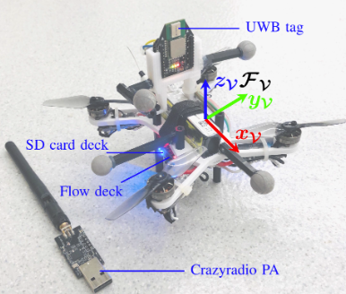

[figure not shown]

[figure not shown]

#### Data Source and images, videos taken from:

1. Wenda Zhao and Abhishek Goudar and Xinyuan Qiao and Angela P. Schoellig. UTIL: An Ultra-wideband Time-difference-of-arrival Indoor Localization Dataset, International Journal of Robotics Research (IJRR), 2022.
2. Särkkä S, Solin A. Applied Stochastic Differential Equations. Cambridge University Press; 2019.
3. Mbalawata, I.S., Särkkä, S. & Haario, H. Parameter estimation in stochastic differential equations with Markov chain Monte Carlo and non-linear Kalman filtering. Comput Stat 28, 1195–1223 (2013).

# Helper Functions

```python
from matplotlib import pyplot as plt
from matplotlib.gridspec import GridSpec
from mpl_toolkits.mplot3d import Axes3D
import numpy as np
from scipy.linalg import expm, logm
import pandas as pd
from scipy.optimize import minimize

def plot_all_fstates(t,x,X,Cov,meas):
    fig, axs = plt.subplots(3, 3, figsize=(8, 8))
    for I in range(3):
        i = 3 * I

        axs[I,0].plot(t, x[i], label='True', color='k')
        axs[I,0].plot(t, X[i], label='Filtered', color='r', linestyle='--')
        axs[I,0].fill_between(t, X[i] - 1*np.sqrt(Cov[:,i,i]), X[i] + 1*np.sqrt(Cov[:,i,i]), color='salmon', alpha=0.4, label='$\sigma$')
        # axs[I,0].plot(t, meas[I], 'kx', markersize=1, label='Measured')
        axs[I,0].set_title('Position')
        axs[I,0].set_xlabel('Time')
        axs[I,0].set_ylabel('Signal')

        axs[I,1].plot(t, x[i+1], color='k')
        axs[I,1].plot(t, X[i+1], color='r', linestyle='--')
        axs[I,1].fill_between(t, X[i+1] - 1*np.sqrt(Cov[:,i+1,i+1]), X[i+1] + 1*np.sqrt(Cov[:,i+1,i+1]), color='salmon', alpha=0.4)
        axs[I,1].set_title('Velocity')
        axs[I,1].set_xlabel('Time')
        axs[I,1].set_ylabel('Signal')

        axs[I,2].plot(t, x[i+2], color='k')
        axs[I,2].plot(t, X[i+2], color='r', linestyle='--')
        axs[I,2].fill_between(t, X[i+2] - 1*np.sqrt(Cov[:,i+2,i+2]), X[i+2] + 1*np.sqrt(Cov[:,i+2,i+2]), color='salmon', alpha=0.4)
        axs[I,2].set_title('Acceleration')
        axs[I,2].set_xlabel('Time')
        axs[I,2].set_ylabel('Signal')
    axs[0,0].legend()
    plt.tight_layout()
    plt.show()

def plot_exp_fstates(t,x,v,a,X,Cov,meas):
    fig, axs = plt.subplots(3, 3, figsize=(8, 8))
    for I in range(3):
        i = 3 * I
        # if I == 0:
        axs[I,0].plot(t, x[I+1], label='True', color='k')
        axs[I,0].plot(t, X[i], label='Filtered', color='r', linestyle='--', alpha=0.8)
        axs[I,0].fill_between(t, X[i] - 1*np.sqrt(Cov[:,i,i]), X[i] + 1*np.sqrt(Cov[:,i,i]), color='salmon', alpha=0.4, label='$\sigma$')
        # axs[I,0].plot(t, meas[I], 'kx', markersize=1, label='Measured')
        axs[I,0].set_title('Position')
        axs[I,0].set_xlabel('Time')
        axs[I,0].set_ylabel('Signal')
        # if I == 0:
        axs[I,1].plot(t, v[I+1], color='k')
        axs[I,1].plot(t, X[i+1], color='r', linestyle='--', alpha=0.8)
        axs[I,1].fill_between(t, X[i+1] - 1*np.sqrt(Cov[:,i+1,i+1]), X[i+1] + 1*np.sqrt(Cov[:,i+1,i+1]), color='salmon', alpha=0.4)
        axs[I,1].set_title('Velocity')
        axs[I,1].set_xlabel('Time')
        axs[I,1].set_ylabel('Signal')
        # if I == 0:
        axs[I,2].plot(t, a[I+1], label='True', color='k')
        axs[I,2].plot(t, X[i+2], color='r', linestyle='--', alpha=0.8)
        axs[I,2].fill_between(t, X[i+2] - 1*np.sqrt(Cov[:,i+2,i+2]), X[i+2] + 1*np.sqrt(Cov[:,i+2,i+2]), color='salmon', alpha=0.4)
        axs[I,2].set_title('Acceleration')
        axs[I,2].set_xlabel('Time')
        axs[I,2].set_ylabel('Signal')
        axs[I,2].set_ylim(-1,1)
    axs[0,0].legend()
    plt.tight_layout()
    plt.show()

def plot_3D_fstates(GP,state,x,landmarks):
    fig = plt.figure(figsize=(8, 8))
    ax = fig.add_subplot(111, projection='3d')
    ax.plot(GP[0,:], GP[3,:], GP[6,:], label='GP', linestyle='--', color='r')
    ax.plot(state[0,:], state[3,:], state[6,:], label='KF', linestyle=':', color='b')
    ax.plot(x[0,:], x[3,:], x[6,:], label='truth', color='k', alpha=0.5)
    ax.plot(landmarks[0], landmarks[1], landmarks[2], 'gx', label='landmarks')
    ax.legend()
    plt.show()

def plot_3D_exp_fstates(GP,state,x,landmarks):
    fig = plt.figure(figsize=(8, 8))
    ax = fig.add_subplot(111, projection='3d')
    ax.plot(GP[0,:], GP[3,:], GP[6,:], label='GP', linestyle='--', color='r')
    ax.plot(state[0,:], state[3,:], state[6,:], label='KF', linestyle=':', color='b')
    ax.plot(x[1,:], x[2,:], x[3,:], label='truth', color='k', alpha=0.5)
    ax.plot(landmarks[0], landmarks[1], landmarks[2], 'gx', label='landmarks')
    ax.legend()
    plt.show()

def kalman_filter_3D(measurements, initial_state, initial_state_covariance, transition_matrix, process_noise_state_covariance, measurement_noise_state_covariance, landmarks):
    num_measurements = measurements.shape[1]
    state_size = initial_state.shape[0]
    measurements_size = measurements.shape[0]

    # Initialize variables
    predicted_state = np.zeros((state_size, num_measurements))
    predicted_state_covariance = np.zeros((num_measurements, state_size, state_size))
    kalman_gain = np.zeros((num_measurements, state_size, measurements_size))
    filtered = np.zeros((state_size, num_measurements))
    filtered_covariance = np.zeros((num_measurements, state_size, state_size))

    # Set initial GP and GP_covariance
    predicted_state[:,0] = initial_state
    predicted_state_covariance[0] = initial_state_covariance
    observation_matrix = np.zeros((measurements_size, state_size))
    for i in range(1, num_measurements):
        # Predict step
        predicted_state[:,i] = np.dot(transition_matrix, filtered[:,i-1])
        predicted_state_covariance[i] = np.dot(np.dot(transition_matrix, filtered_covariance[i-1]), transition_matrix.T) + process_noise_state_covariance

        # Update step
        h, H = calculate_measurements_and_jacobian(np.array([predicted_state[[0,3,6],i]]).T, landmarks)
        # observation_matrix = np.hstack((H,np.zeros((H.shape[0],state_size-3))))
        jj=0
        for j in [0, 3, 6]:
            observation_matrix[:,j] = H[:,jj] #np.hstack((H,np.zeros((H.shape[0],state_size-1))))
            jj+=1
        # print(observation_matrix)
        # print("x", predicted_state[i-1,0],"y",measurements[:,i-1] ,"h(x)", h, "H(x)", H.T)
        innovation = (h-measurements[:,i-1])  #+ np.sum(H*(landmarks-predicted_state[i-1,0]).T,axis=1) #+ h # np.sum(jacobian*(landmarks-pos).T,axis=1)
        innovation_state_covariance = np.dot(np.dot(observation_matrix, predicted_state_covariance[i]), observation_matrix.T) + measurement_noise_state_covariance
        kalman_gain[i] = np.dot(np.dot(predicted_state_covariance[i], observation_matrix.T), np.linalg.inv(innovation_state_covariance))
```

```python
        filtered[:,i] = predicted_state[:,i] + np.dot(kalman_gain[i], innovation)
        filtered_covariance[i] = np.dot((np.eye(state_size) - np.dot(kalman_gain[i], observation_matrix)), predicted_state_covariance[i])
    return filtered, filtered_covariance

def kalman_filter_RTS(measurements, initial_state, initial_state_covariance, transition_matrix, process_noise_state_covariance, measurement_noise_state_covariance, landmarks):
    num_measurements = measurements.shape[1]
    state_size = initial_state.shape[0]
    measurements_size = measurements.shape[0]

    # Initialize variables
    predicted_state = np.zeros((state_size, num_measurements))
    predicted_state_covariance = np.zeros((num_measurements, state_size, state_size))
    kalman_gain = np.zeros((num_measurements, state_size, measurements_size))
    filtered = np.zeros((state_size, num_measurements))
    filtered_covariance = np.zeros((num_measurements, state_size, state_size))

    # Set initial GP and GP_covariance
    predicted_state[:,0] = initial_state
    predicted_state_covariance[0] = initial_state_covariance
    observation_matrix = np.zeros((measurements_size, state_size))
    for i in range(1, num_measurements):
        # Predict step
        predicted_state[:,i] = np.dot(transition_matrix, filtered[:,i-1])
        predicted_state_covariance[i] = np.dot(np.dot(transition_matrix, filtered_covariance[i-1]), transition_matrix.T) + process_noise_state_covariance

        # Update step
        h, H = calculate_measurements_and_jacobian(np.array([predicted_state[[0,3,6],i]]).T, landmarks)
        # observation_matrix = np.hstack((H,np.zeros((H.shape[0],state_size-3))))
        jj=0
        for j in [0, 3, 6]:
            observation_matrix[:,j] = H[:,jj] #np.hstack((H,np.zeros((H.shape[0],state_size-1))))
            jj+=1
        # print(observation_matrix)
        # print("x", predicted_state[:,i],"h(x)", h, "H(x)", H.T)
        innovation = (h-measurements[:,i-1])  #+ np.sum(H*(landmarks-predicted_state[i-1,0]).T,axis=1) #+ h # np.sum(jacobian*(landmarks-pos).T,axis=1)
        innovation_state_covariance = np.dot(np.dot(observation_matrix, predicted_state_covariance[i]), observation_matrix.T) + measurement_noise_state_covariance
        kalman_gain[i] = np.dot(np.dot(predicted_state_covariance[i], observation_matrix.T), np.linalg.inv(innovation_state_covariance + np.eye(measurements_size)*1e-6))

        filtered[:,i] = predicted_state[:,i] + np.dot(kalman_gain[i], innovation)
        filtered_covariance[i] = np.dot((np.eye(state_size) - np.dot(kalman_gain[i], observation_matrix)), predicted_state_covariance[i])

    # add smoother
    smoothed = np.zeros((state_size, num_measurements))
    smoothed_covariance = np.zeros((num_measurements, state_size, state_size))
    smoothed[:,num_measurements-1] = filtered[:,num_measurements-1]
    smoothed_covariance[num_measurements-1] = filtered_covariance[num_measurements-1]
    for i in range(num_measurements-2, -1, -1):
        smoother = np.dot(filtered_covariance[i], np.dot(transition_matrix.T, np.linalg.inv(np.eye(9)*1e-6 + predicted_state_covariance[i+1])))
        smoothed[:,i] = filtered[:,i] + np.dot(smoother, smoothed[:,i+1] - predicted_state[:,i+1])
        smoothed_covariance[i] = filtered_covariance[i] + np.dot(np.dot(smoother, smoothed_covariance[i+1] - predicted_state_covariance[i+1]), smoother.T)

    return smoothed, smoothed_covariance

def kalman_filter_q(parameters,measurements, initial_state, initial_state_covariance, measurement_noise_state_covariance, landmarks):
    num_measurements = measurements.shape[1]
    state_size = initial_state.shape[0]
    measurements_size = measurements.shape[0]

    # Initialize variables
    predicted_state = np.zeros((state_size, num_measurements))
    predicted_state_covariance = np.zeros((num_measurements, state_size, state_size))
    kalman_gain = np.zeros((num_measurements, state_size, measurements_size))
    filtered = np.zeros((state_size, num_measurements))
    filtered_covariance = np.zeros((num_measurements, state_size, state_size))
    ll = 0
    l, s = parameters
    q = s**2 * (2 * l)**(5) / 6
    F = np.array([[0, 1, 0],[0, 0, 1],[-l**2, -3*l**2, -3*l]])
    LQL = q * np.array([[0,0,0],[0,0,0],[0,0,1]])
    F = np.kron(np.eye(3), F)
    LQL = np.kron(np.eye(3),LQL)
    G = np.hstack((F, LQL))
    G = np.vstack((G, np.hstack((np.zeros((9,9)), -F.T)) ))
    G = expm(dt * G)
    A = G[0:9,0:9]
    S = G[0:9,9:18] @ A.T + np.eye(9) * 1e-12
    transition_matrix = A
    process_noise_state_covariance = S
    # Set initial GP and GP_covariance
    predicted_state[:,0] = initial_state
    predicted_state_covariance[0] = initial_state_covariance
    observation_matrix = np.zeros((measurements_size, state_size))
    for i in range(1, num_measurements):
        # Predict step
        predicted_state[:,i] = np.dot(transition_matrix, filtered[:,i-1])
        predicted_state_covariance[i] = np.dot(np.dot(transition_matrix, filtered_covariance[i-1]), transition_matrix.T) + process_noise_state_covariance

        # Update step
        h, H = calculate_measurements_and_jacobian(np.array([predicted_state[[0,3,6],i]]).T, landmarks)
        # observation_matrix = np.hstack((H,np.zeros((H.shape[0],state_size-3))))
        jj=0
        for j in [0, 3, 6]:
            observation_matrix[:,j] = H[:,jj] #np.hstack((H,np.zeros((H.shape[0],state_size-1))))
            jj+=1
        # print(observation_matrix)
        # print("x", predicted_state[i-1,0],"y",measurements[:,i-1] ,"h(x)", h, "H(x)", H.T)
        innovation = (h-measurements[:,i-1])  #+ np.sum(H*(landmarks-predicted_state[i-1,0]).T,axis=1) #+ h # np.sum(jacobian*(landmarks-pos).T,axis=1)
        innovation_state_covariance = np.dot(np.dot(observation_matrix, predicted_state_covariance[i]), observation_matrix.T) + measurement_noise_state_covariance
        kalman_gain[i] = np.dot(np.dot(predicted_state_covariance[i], observation_matrix.T), np.linalg.inv(innovation_state_covariance))
```

```python
        filtered[:,i] = predicted_state[:,i] + np.dot(kalman_gain[i], innovation)
        filtered_covariance[i] = np.dot((np.eye(state_size) - np.dot(kalman_gain[i], observation_matrix)), predicted_state_covariance[i])

        ll += 0.5 * np.sum( np.log( np.linalg.det(2 * np.pi * innovation_state_covariance) ) ) + 0.5 * np.dot(innovation.T, np.linalg.solve(innovation_state_covariance, innovation))
    return ll

def calculate_measurements_and_jacobian(position, landmarks):
    num_landmarks = landmarks.shape[1]
    num_state = position.shape[0]
    measurements = np.zeros(num_landmarks)
    jacobian = np.zeros((num_landmarks, num_state))

    for i in range(num_landmarks):
        landmark = landmarks[:,i]
        delta = landmark - position.flatten()
        distance = np.linalg.norm(delta)

        measurements[i] = distance
        jacobian[i,:] = delta / distance

    return measurements, jacobian

def calculate_distance(position, landmarks):
    """distance between 3D pos and multiple landmarks"""
    num_landmarks = landmarks.shape[1]
    num_meas = position.shape[1]
    distance = np.zeros((num_landmarks, num_meas))
    for i in range(num_landmarks):
        diff = np.array([landmarks[:,i]]).T - position
        distance[i] = np.sqrt(np.sum(diff**2, axis=0))

    return distance

# pos = np.random.randn(2, 1)
# landmarks = np.random.rand(2, 3) * 3
# measurements, jacobian = calculate_measurements_and_jacobian(pos, landmarks)
# print("pos:\n", pos)
# print("landmarks:\n", landmarks)
# print("mes:\n", measurements)
# print("jac:\n", jacobian)
# print("disError:\n", np.sum(jacobian*(landmarks-pos).T,axis=1) ,)
# plt.plot(landmarks[0], landmarks[1], 'rx')
# plt.plot(pos[0], pos[1], 'bo')
# for i in range(landmarks.shape[1]):
#     plt.plot([pos[0,0], landmarks[0,i]], [pos[1,0], landmarks[1,i]],label=measurements[i])
# plt.legend()
# plt.show()
```

# Simulation Test Run

This section represents a first test scenario for the proposed model. Motion due to a noise-on-acceleration model is simulated, measurements with added white noise from randomly positioned landmarks in 3D space are generated based on this data, and the EKF framework is run.

The results suggest that the approach is feasable. The estimators with the classic model and the GP SDE model are performing well in simulation, even providing decent estiamtes for the unobserved velocity and acceleration states.

```
EKF MAE 0.0878666290508188 GP MAE 0.0878666290508188
EKF RMSE 0.21154456358902768 GP RMSE 0.21154456358902768
EKF state covariance 0.0065966646352099405 0.0011611118768760976 0.0009829931851852447
GP state covariance 0.0065647795001268 0.0011572719429112064 0.000979793259849892
EKF state standard deviation,  0.07731772726269434 0.032820668643590574 0.03045195410798771
GP state standard deviation,  0.0771344817854121 0.0327673617728235 0.030402739866003885
```

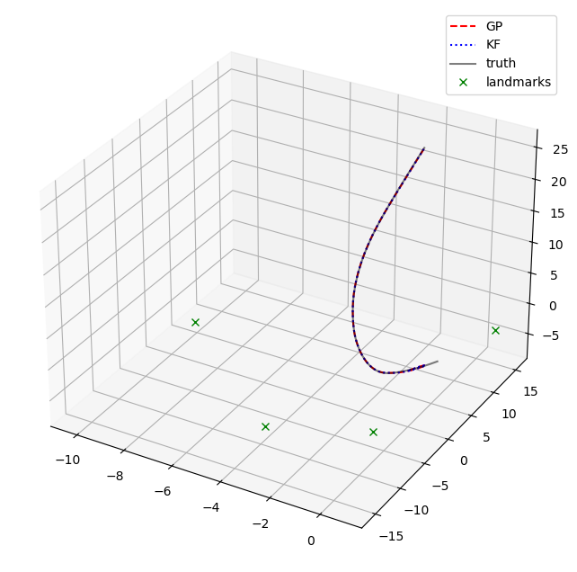

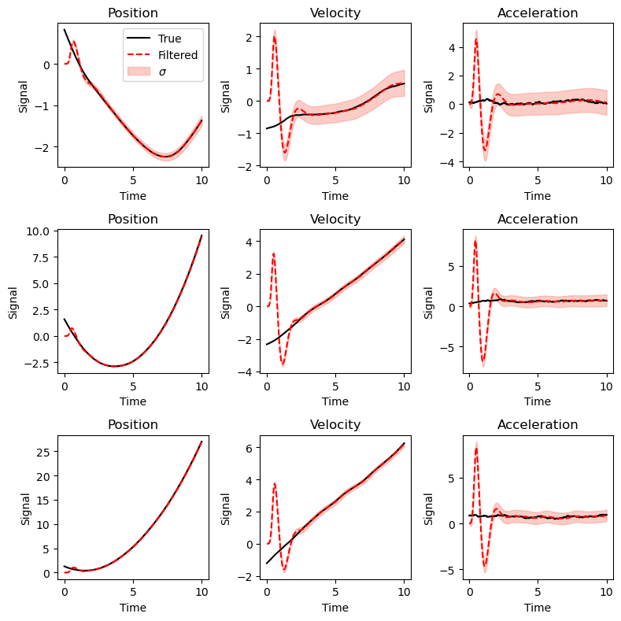

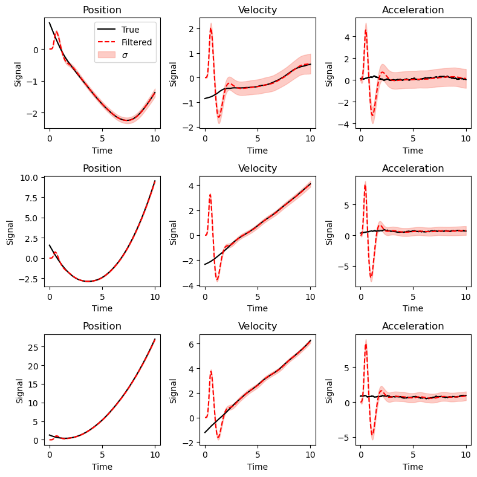

```python
T = 10
t = np.linspace(0, T, T*50)
dt = t[1] - t[0]
nx = 9

# constatnt acceleration model
A = np.array([[1, dt, 0.5 * dt ** 2],
                  [0,  1, dt],
                  [0,  0, 1]])
A = np.kron(np.eye(3),A)
x0 = np.random.randn(nx)

# simulate the system
x = np.zeros((nx, t.shape[0]))
L = np.array([0,0,1,0,0,1,0,0,1]).T
n = np.random.randn(nx) * 0.1
for i in range(t.shape[0]):
    x[:, i] = x0
    n =  L * (np.random.randn(nx)) * 0.02
    x0 = A @ x0 + n

l = 0.01
s = 1
q = 1#s**2 * (2 * l)**(5) / 6
F = np.array([[0, 1, 0],[0, 0, 1],[-l**2, -3*l**2, -3*l]])
LQL = q * np.array([[0,0,0],[0,0,0],[0,0,1]])
F = np.kron(np.eye(3), F)
LQL = np.kron(np.eye(3),LQL)
G = np.hstack((F, LQL))
G = np.vstack((G, np.hstack((np.zeros((9,9)), -F.T)) ))
G = expm(dt * G)
A = G[0:9,0:9]
S = G[0:9,9:18] @ A.T + np.eye(9) * 1e-12

Ac = np.array([[1, dt, 0.5 * dt ** 2],
               [0,  1, dt],
               [0,  0, 1]])
Ac = np.kron(np.eye(3),Ac)

x0 = np.random.randn(nx) * np.array([1, 0.1, 0.01, 1, 0.1, 0.01, 1, 0.1, 0.01])

n_landmarks = 4
landmarks = np.random.randn(3, n_landmarks) * 10#np.array([[-1,1,2]])#
Y = calculate_distance(x[[0,3,6],:], landmarks) + 0.001 * np.random.randn(n_landmarks, t.shape[0])

H = np.array([[1, 0, 0, 0, 0, 0, 0, 0, 0],[0, 0, 0, 1, 0, 0, 0, 0, 0],[0, 0, 0, 0, 0, 0, 1, 0, 0]])
y = np.array(x[[0,3,6]])
y += 0.1 * np.random.randn(y.shape[0], y.shape[1])

P_0 = 1 * np.eye(A.shape[0])
Q1 = 1 * np.kron(np.eye(3),np.array([[dt**5/20, dt**4/8, dt**3/6], [dt**4/8, dt**3/3, dt**2/2], [dt**3/6, dt**2/2, dt]]))
Q2 = S
R = 1e-2 * np.eye(Y.shape[0])

state, cov = kalman_filter_3D(Y, x0, P_0, Ac, Q1, R, landmarks)
GP, GP_cov = kalman_filter_3D(Y, x0, P_0,  A, Q2, R, landmarks)

print("EKF MAE",np.mean(np.abs(x[[0,3,6],:]-GP[[0,3,6],:])), "GP MAE",np.mean(np.abs(x[[0,3,6],:]-GP[[0,3,6],:])))
print("EKF RMSE",np.sqrt(np.mean((x[[0,3,6],:]-GP[[0,3,6],:])**2)),"GP RMSE", np.sqrt(np.mean((x[[0,3,6],:]-GP[[0,3,6],:])**2)))
print("EKF state covariance", np.mean(cov[:,0,0]), np.mean(cov[:,3,3]), np.mean(cov[:,6,6]))
print("GP state covariance",np.mean(GP_cov[:,0,0]), np.mean(GP_cov[:,3,3]), np.mean(GP_cov[:,6,6]))
print("EKF state standard deviation, ", np.mean(np.sqrt(cov[:,0,0])), np.mean(np.sqrt(cov[:,3,3])), np.mean(np.sqrt(cov[:,6,6])))
print("GP state standard deviation, ", np.mean(np.sqrt(GP_cov[:,0,0])), np.mean(np.sqrt(GP_cov[:,3,3])), np.mean(np.sqrt(GP_cov[:,6,6])))

plot_3D_fstates(GP,state,x,landmarks)
plot_all_fstates(t,x,GP,GP_cov,Y)
plot_all_fstates(t,x,state,cov,Y)
```

# Experimental Test Run

Two tests are shown in this section; one with more variation in some of the states than others throughout the test trajectory, and another with dynamics present in all the states throughout the test trajectory.

To conclude, this project has established that GP-equivelant SDE models can successfully be used in place of classical models for state estimation purposes. In the testing done, it was also observed that the confidence bounds that a KF framework yields are possible more accurate with the GP-SDE model substitute than classical constant acceleration models.

As future work, it would be interesting to generalize the approach taken in this project to include landmark mapping; that is, convert the localization-only problem to Simultanious Localization and Mapping (SLAM). SLAM can be done by augmenting the current state with states representing the location of each landmark. The same models can also be extended to formulate an alternative approach to classic Inertial Navigation Systems where similar dynamic and measurements models are involved. Finally, the same problem can be revisited after adding more sources of measurements rather than only consider position measurements.

```
EKF MAE 0.011094690938935356 GP MAE 0.011094690938935356
EKF RMSE 0.042404823895187786 GP RMSE 0.042404823895187786
EKF state covariance 0.0021787110226859415 0.001740697638256191 0.009513780430221162
GP state covariance 0.0014184893867938736 0.0011412618505301632 0.0058774264907579185
EKF state standard deviation,  0.046634486040710674 0.0416884608542546 0.09738733313404588
GP state standard deviation,  0.03761952805244669 0.03374755201662753 0.07652144803567207
```

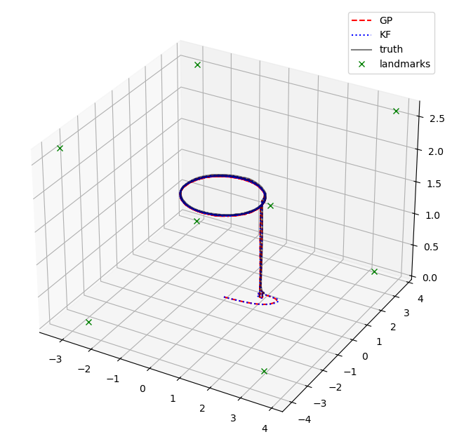

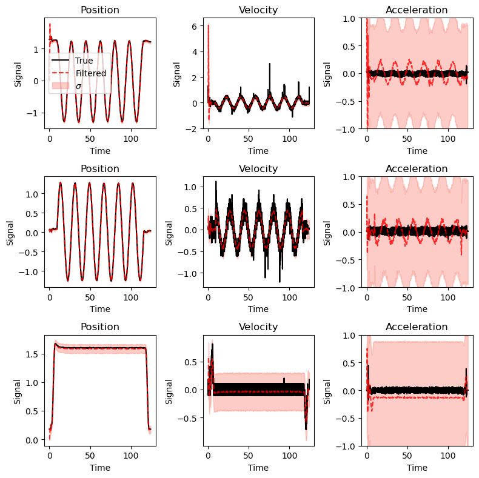

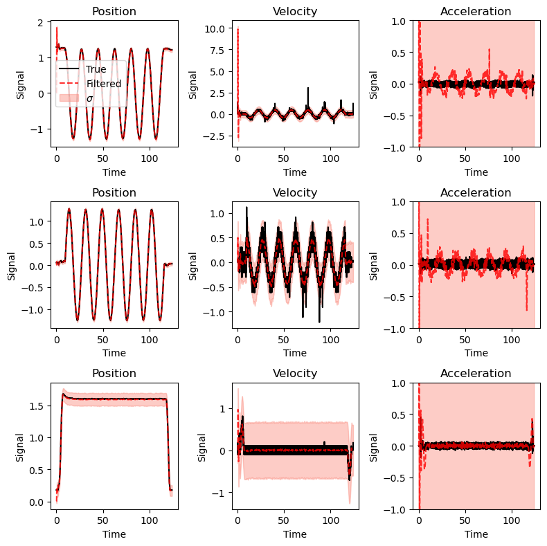

```python
acc = pd.read_csv('test_c1_t1_acc.txt', delim_whitespace=True)+np.array([[0, 0, 0, -1]]) # removing gravity from body acceleration
gyro = pd.read_csv('test_c1_t1_gyro.txt', delim_whitespace=True)
uwb = pd.read_csv('test_c1_t1_uwb.txt', delim_whitespace=True).T
pose = pd.read_csv('test_c1_t1_pose.txt', delim_whitespace=True).T
landmarks = pd.read_csv('test_c1_t1_anchors.txt', delim_whitespace=True, header=None).T
acc = acc.to_numpy().T
gyro = gyro.to_numpy()
uwb = uwb.to_numpy()
pose = pose.to_numpy() + np.array([[0, 0, 0, 0.1, 0, 0, 0, 0]]).T # translating pose to drone CG from tag CG
v = pose[0:4,:].copy()
# numerical derivative of v
# v[1:4,0:-2] = (v[1:4,2:] - 4*v[1:4,1:-1] + 3*v[1:4,0:-2])/(v[0,1]-v[0,0])/2
# v[1:4,1:] = (v[1:4,1:] - v[1:4,0:-1])/(v[0,1]-v[0,0])
v[1:4,1:-1] = (v[1:4,2:] - v[1:4,0:-2])/(v[0,1]-v[0,0])/2
landmarks = landmarks.to_numpy()
n_landmarks = landmarks.shape[1]
Y = uwb # 0.01 * np.random.randn(uwb.shape[0], uwb.shape[1])
t = pose[0,:]
dt = t[1] - t[0]

l = 0.5 #0.8
s = 5 #2.75
q = s**2 * (2 * l)**(5) / 6
F = np.array([[0, 1, 0],[0, 0, 1],[-l**2, -3*l**2, -3*l]])
LQL = q * np.array([[0,0,0],[0,0,0],[0,0,1]])
F = np.kron(np.eye(3), F)
LQL = np.kron(np.eye(3),LQL)
G = np.hstack((F, LQL))
G = np.vstack((G, np.hstack((np.zeros((9,9)), -F.T)) ))
G = expm(dt * G)
A = G[0:9,0:9]
S = G[0:9,9:18] @ A.T + np.eye(9) * 1e-12

Ac = np.array([[1, dt, 0.5 * dt ** 2],
               [0,  1, dt],
               [0,  0, 1]])
Ac = np.kron(np.eye(3),Ac)

x0 = np.random.randn(nx) * .01#np.array([1, 0.1, 0.01, 1, 0.1, 0.01, 1, 0.1, 0.01])
# x[:,0] = np.random.randn(nx) * np.array([1, 0.1, 0.01, 1, 0.1, 0.01, 1, 0.1, 0.01])
P_0 = 1 * np.eye(A.shape[0])

Q1 = s**2 * np.kron(np.eye(3),np.array([[dt**5/20, dt**4/8, dt**3/6], [dt**4/8, dt**3/3, dt**2/2], [dt**3/6, dt**2/2, dt]]))
Q2 = S #np.kron(np.eye(3),np.array([[0,0,0],[0,0,0],[0,0,25]]));
R = 1e-1 * np.eye(Y.shape[0])

state, cov = kalman_filter_3D(Y, x0, P_0, Ac, Q1, R, landmarks)
GP, GP_cov = kalman_filter_3D(Y, x0, P_0,  A, Q2, R, landmarks)

print("EKF MAE",np.mean(np.abs(pose[1:4,:]-GP[[0,3,6],:])), "GP MAE",np.mean(np.abs(pose[1:4,:]-GP[[0,3,6],:])))
print("EKF RMSE",np.sqrt(np.mean((pose[1:4,:]-GP[[0,3,6],:])**2)),"GP RMSE", np.sqrt(np.mean((pose[1:4,:]-GP[[0,3,6],:])**2)))
print("EKF state covariance", np.mean(cov[:,0,0]), np.mean(cov[:,3,3]), np.mean(cov[:,6,6]))
print("GP state covariance",np.mean(GP_cov[:,0,0]), np.mean(GP_cov[:,3,3]), np.mean(GP_cov[:,6,6]))
print("EKF state standard deviation, ", np.mean(np.sqrt(cov[:,0,0])), np.mean(np.sqrt(cov[:,3,3])), np.mean(np.sqrt(cov[:,6,6])))
print("GP state standard deviation, ", np.mean(np.sqrt(GP_cov[:,0,0])), np.mean(np.sqrt(GP_cov[:,3,3])), np.mean(np.sqrt(GP_cov[:,6,6])))

plot_3D_exp_fstates(GP,state,pose,landmarks)
plot_exp_fstates(t,pose,v,acc,GP,GP_cov,Y)
plot_exp_fstates(t,pose,v,acc,state,cov,Y)
```

```
EKF MAE 0.0370841750542956 GP MAE 0.0370841750542956
EKF RMSE 0.07308394195483589 GP RMSE 0.07308394195483589
EKF state covariance 0.003057169264560726 0.0023825302527701224 0.01332988411908722
GP state covariance 0.0010031183376696179 0.0007864477154618664 0.004215227713078899
EKF state standard deviation,  0.0552569460032851 0.04878457468010512 0.1152739469728766
GP state standard deviation,  0.031621065024600555 0.028002068150601803 0.06473938858954359
```

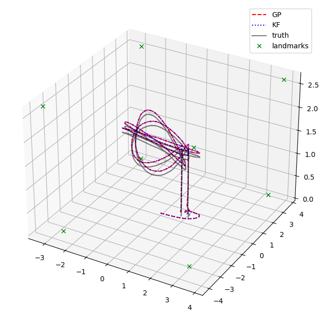

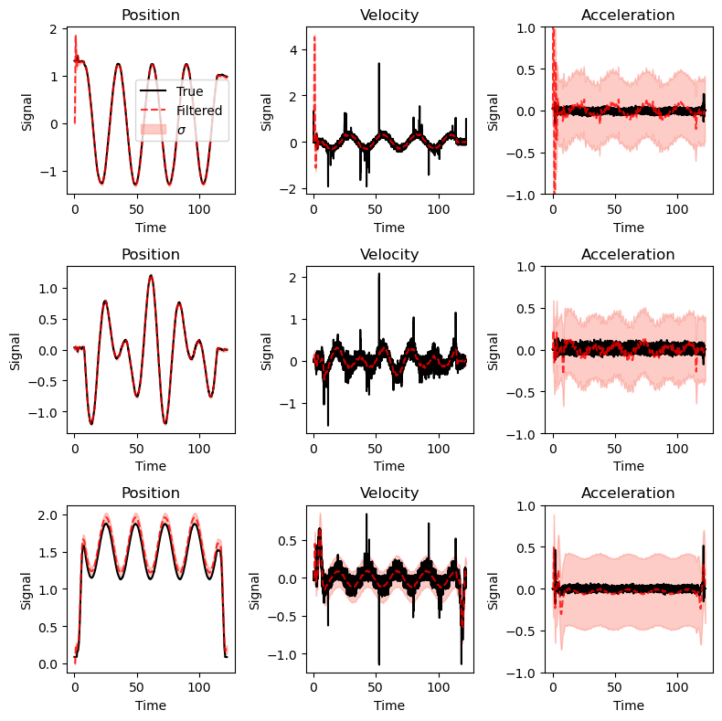

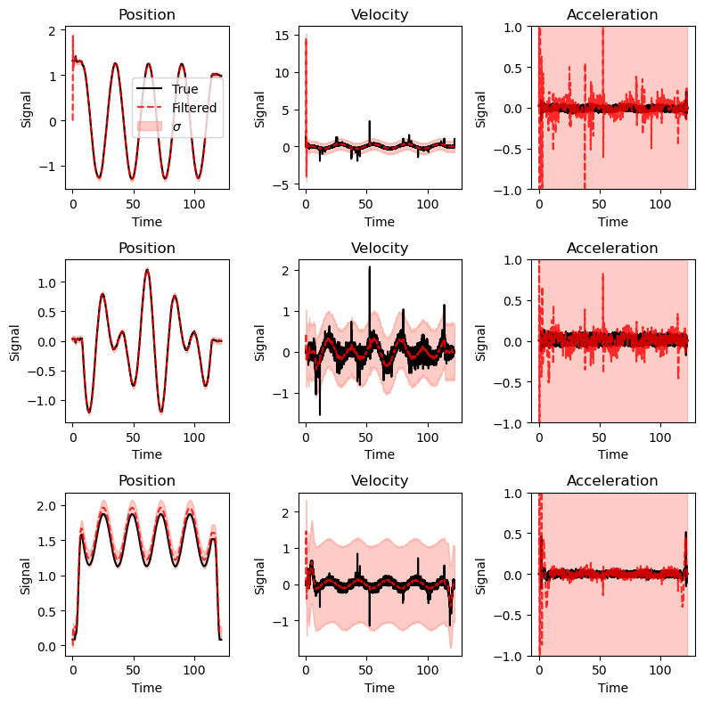

```python
acc = pd.read_csv('test_c1_t2_acc.txt', delim_whitespace=True)+np.array([[0, 0, 0, -1]]) # removing gravity from body acceleration
gyro = pd.read_csv('test_c1_t2_gyro.txt', delim_whitespace=True)
uwb = pd.read_csv('test_c1_t2_uwb.txt', delim_whitespace=True).T
pose = pd.read_csv('test_c1_t2_pose.txt', delim_whitespace=True).T
landmarks = pd.read_csv('test_c1_t1_anchors.txt', delim_whitespace=True, header=None).T
acc = acc.to_numpy().T
gyro = gyro.to_numpy()
uwb = uwb.to_numpy()
pose = pose.to_numpy()# translating pose to drone CG from tag CG
v = pose[0:4,:].copy() + np.random.randn(4, pose.shape[1]) * 0.0001
# numerical derivative of v
# v[1:4,0:-2] = (v[1:4,2:] - 4*v[1:4,1:-1] + 3*v[1:4,0:-2])/(v[0,1]-v[0,0])/2
# v[1:4,1:] = (v[1:4,1:] - v[1:4,0:-1])/(v[0,1]-v[0,0])
v[1:4,1:-1] = (v[1:4,2:] - v[1:4,0:-2])/(v[0,1]-v[0,0])/2
landmarks = landmarks.to_numpy()
n_landmarks = landmarks.shape[1]
Y = uwb # 0.01 * np.random.randn(uwb.shape[0], uwb.shape[1])
t = pose[0,:]
dt = t[1] - t[0]

l = 0.2 #0.8
s = 15 #2.75
q = s**2 * (2 * l)**(5) / 6
F = np.array([[0, 1, 0],[0, 0, 1],[-l**2, -3*l**2, -3*l]])
LQL = q * np.array([[0,0,0],[0,0,0],[0,0,1]])
F = np.kron(np.eye(3), F)
LQL = np.kron(np.eye(3),LQL)
G = np.hstack((F, LQL))
G = np.vstack((G, np.hstack((np.zeros((9,9)), -F.T)) ))
G = expm(dt * G)
A = G[0:9,0:9]
S = G[0:9,9:18] @ A.T + np.eye(9) * 1e-12

Ac = np.array([[1, dt, 0.5 * dt ** 2],
               [0,  1, dt],
               [0,  0, 1]])
Ac = np.kron(np.eye(3),Ac)

x0 = np.random.randn(nx) * .01#np.array([1, 0.1, 0.01, 1, 0.1, 0.01, 1, 0.1, 0.01])
# x[:,0] = np.random.randn(nx) * np.array([1, 0.1, 0.01, 1, 0.1, 0.01, 1, 0.1, 0.01])
P_0 = 1 * np.eye(A.shape[0])

Q1 = s**2 * np.kron(np.eye(3),np.array([[dt**5/20, dt**4/8, dt**3/6], [dt**4/8, dt**3/3, dt**2/2], [dt**3/6, dt**2/2, dt]]))
Q2 = S #np.kron(np.eye(3),np.array([[0,0,0],[0,0,0],[0,0,25]]));
R = 1e-1 * np.eye(Y.shape[0])

state, cov = kalman_filter_3D(Y, x0, P_0, Ac, Q1, R, landmarks)
GP, GP_cov = kalman_filter_3D(Y, x0, P_0,  A, Q2, R, landmarks)

print("EKF MAE",np.mean(np.abs(pose[1:4,:]-GP[[0,3,6],:])), "GP MAE",np.mean(np.abs(pose[1:4,:]-GP[[0,3,6],:])))
print("EKF RMSE",np.sqrt(np.mean((pose[1:4,:]-GP[[0,3,6],:])**2)),"GP RMSE", np.sqrt(np.mean((pose[1:4,:]-GP[[0,3,6],:])**2)))
print("EKF state covariance", np.mean(cov[:,0,0]), np.mean(cov[:,3,3]), np.mean(cov[:,6,6]))
print("GP state covariance",np.mean(GP_cov[:,0,0]), np.mean(GP_cov[:,3,3]), np.mean(GP_cov[:,6,6]))
print("EKF state standard deviation, ", np.mean(np.sqrt(cov[:,0,0])), np.mean(np.sqrt(cov[:,3,3])), np.mean(np.sqrt(cov[:,6,6])))
print("GP state standard deviation, ", np.mean(np.sqrt(GP_cov[:,0,0])), np.mean(np.sqrt(GP_cov[:,3,3])), np.mean(np.sqrt(GP_cov[:,6,6])))

plot_3D_exp_fstates(GP,state,pose,landmarks)
plot_exp_fstates(t,pose,v,acc,GP,GP_cov,Y)
plot_exp_fstates(t,pose,v,acc,state,cov,Y)
```

# Hyperparameter Inference

In this section, two approaches are considered to perform the hyperparameter inference. First is Maximum Likelihood (ML) optimization based on the EKF recursion, which provides the posterior of the parameters conditioned on the measurements. Second is Expectation Maximization (EM) where the problem is posed considering the posterior of the parameters conditioned on the smoothed states. With EM, the E-step is performed via smoothing the EKF estimates, and the M-step is performed usually via optimization.

With the ML approach, scipy minimize is used to find the parameteres. While Markov Chain Monte Carlo (MCMC) is used with the EM appraoch. This choice is due to the higher comutational complexity required by EM and that MCMC has perfomed well during testing.

```python
f = lambda p: kalman_filter_q(p, Y, x0, P_0, R, landmarks)

p_MLE = []
for i in range(1):
    # Use the minimize function to find the minimum likelihood      jac=fprime,
    result = minimize(f, np.random.rand(2)*3, method='L-BFGS-B', tol=1e-2, bounds=[(1e-3, None), (1e-3, None)], options={'disp': False, 'maxiter': 10, 'full_output':False})
    # Print the optimized result
    print("Try:",i+1,"Optimized result:", result.x,"Optimized likelihood:", result.fun)
    X = np.array([result.x[0], result.x[1], result.fun])
    p_MLE.append(X)

p_MLE = np.array(p_MLE)
print("Mean:",np.mean(p_MLE, axis=0))
print("Std:",np.std(p_MLE, axis=0))
print("Median:",np.median(p_MLE, axis=0))
print("Min:",np.min(p_MLE, axis=0))
print("Max:",np.max(p_MLE, axis=0))
```

```
Try: 1 Optimized result: [1.40712422 0.67375136] Optimized likelihood: -42280.13932325473
Mean: [ 1.40712422e+00  6.73751355e-01 -4.22801393e+04]
Std: [0. 0. 0.]
Median: [ 1.40712422e+00  6.73751355e-01 -4.22801393e+04]
Min: [ 1.40712422e+00  6.73751355e-01 -4.22801393e+04]
Max: [ 1.40712422e+00  6.73751355e-01 -4.22801393e+04]
```

EM where

- the E-step is performed via smoothing the EKF estimates
- the M-step is performed using MCMC to sample the posterior and yield parameter values from the sampled likelihood

```
Mean [0.77490935 3.05084282] Std [0.17577592 0.0071115 ] Median [0.76181022 3.05095377]
Initial likelihood 7.741322655905848e+18 Final likelihood at median 1.9472206544761406
Proportion of accepted samples 94.13 %
```

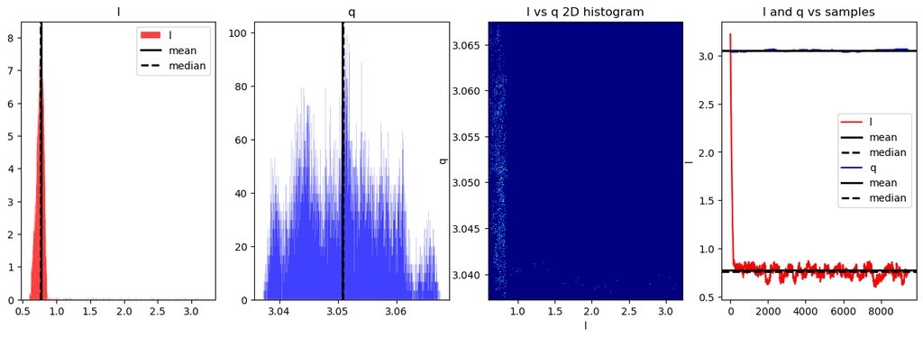

```python
# Af = lambda l, q: np.kron(np.eye(3),expm(- dt * np.array([[0, 1, 0],[0, 0, 1],[-l**2, -3*l**2, -3*l]])))
# Sf = lambda l, q: np.eye(9) + dt * Af(l, q) @ np.array([0,0,0,0,0,0,0,0,1]) * q * np.array([0,0,0,0,0,0,0,0,1]).T @ Af(l, q).T + np.eye(9) * 1e-10
# ll = lambda l, q: 0.5 * np.sum( 2 * np.pi * Sf(l, q) ) + (xn - Af(l, q) * xp).T * np.linalg.inv(Sf(l, q)) * (xn - Af(l, q) * xp)

# Af = lambda l, q: np.kron(np.eye(3), np.array([[np.exp(-dt*l) + (dt**2*l**2*np.exp(-dt*l))/2 + dt*l*np.exp(-dt*l),         dt*np.exp(-dt*l) + dt**2*l*np.exp(-dt*l),                                      (dt**2*np.exp(-dt*l))/2],
# [                              -(dt**2*l**2*np.exp(-dt*l))/2,        np.exp(-dt*l)*(- dt**2*l**2 + dt*l + 1),                            -(dt*np.exp(-dt*l)*(dt*l - 2))/2],
# [           (dt**2*l**4*np.exp(-dt*l))/2 - dt*l**2*np.exp(-dt*l), dt**2*l**2*np.exp(-dt*l) - 3*dt*l**2*np.exp(-dt*l), np.exp(-dt*l) + (dt**2*l**2*np.exp(-dt*l))/2 - 2*dt*l*np.exp(-dt*l)]]))

# Sf = lambda l, q: np.eye(9)*1e-10 + np.kron(np.eye(3), np.array([[(3*q)/(16*l**5) - (q*np.exp(-2*dt*l)*(16*dt**4*l**4 + 32*dt**3*l**2 + 48*dt**2*l**2 + 48*dt*l + 24))/(128*l**5),                                                                    (dt**4*q*np.exp(-2*dt*l))/8,   (q*np.exp(-2*dt*l)*(2*dt*l - np.exp(2*dt*l) + 2*dt**2*l**2 + 4*dt**3*l**2 - 2*dt**4*l**4 + 1))/(16*l**2)],
# [                                                                             (dt**4*q*np.exp(-2*dt*l))/8, q/(16*l**2) - (q*np.exp(-2*dt*l)*(2*dt**4*l**4 - 4*dt**3*l**2 + 2*dt**2*l**2 + 2*dt*l + 1))/(16*l**2),                                                          (dt**2*q*np.exp(-2*dt*l)*(dt*l - 2)**2)/8],
# [         (q*np.exp(-2*dt*l)*(2*dt*l - np.exp(2*dt*l) + 2*dt**2*l**2 + 4*dt**3*l**2 - 2*dt**4*l**4 + 1))/(16*l**2),                                                       (dt**2*q*np.exp(-2*dt*l)*(dt*l - 2)**2)/8, (3*q)/(16*l) - (q*np.exp(-2*dt*l)*(2*dt**4*l**4 - 12*dt**3*l**2 + 22*dt**2*l**2 - 10*dt*l + 3))/(16*l)]]))

# ll = lambda l, q: np.sum( 0.5 * np.linalg.det( 2 * np.pi * Sf(l, q) ) + (xn - Af(l, q) @ xp).T @ np.linalg.inv(Sf(l, q)) @ (xn - Af(l, q) @ xp) )

# resample the data to speed up the optimization
s = 1000
dt = 0.001 * s

def ll(p):
    """log likelihood function for the metropolis hastings algorithm"""
    l, std = p
    F = np.array([[0, 1, 0],[0, 0, 1],[-l**2, -3*l**2, -3*l]])
    q = std**2 * (2 * l)**(5) / 6
    LQL = q * np.array([[0,0,0],[0,0,0],[0,0,1]])
    F = np.kron(np.eye(3), F)
    LQL = np.kron(np.eye(3),LQL)
    G = np.hstack((F, LQL))
    G = np.vstack((G, np.hstack((np.zeros((9,9)), -F.T)) ))
    G = expm(dt * G)
    A = G[0:9,0:9]
    S = G[0:9,9:18] @ A.T + np.eye(9) * 1e-12

    Af = A
    Sf = S

    return 0.5 * np.sum( 2 * np.pi * np.linalg.det(Sf) + (xn - Af @ xp).T @ np.linalg.inv(Sf) @ (xn - Af @ xp) )

def ll_metropolis_hastings(target_distribution, initial_state, num_samples, proposal_distribution):
    samples = [initial_state]
    current_state = initial_state

    for _ in range(num_samples):
        proposed_state = proposal_distribution(current_state)
        acceptance_ratio = target_distribution(current_state) - target_distribution(proposed_state)
        acceptance_probability = min( 1, np.exp(acceptance_ratio) )

        if np.random.uniform() < acceptance_probability:
            current_state = proposed_state

            samples.append(current_state)

    return samples

def proposal_distribution(x):
    return x + np.random.randn(2) * [.01, .0001]

def target_distribution(x):
    return ll(np.exp(x)) - np.sum((x))

R = 1e-1 * np.eye(Y.shape[0])

xn = GP[:,1:-1:s]
xp = GP[:,0:-2:s]

N = 10000
sss = ll_metropolis_hastings(target_distribution, np.exp(0*np.random.rand(2)), N, proposal_distribution)

GP, GP_cov = kalman_filter_RTS(Y, x0, P_0, F, S, R, landmarks)

samples = np.array(sss).T
l, q = np.mean(np.exp(samples),axis=1)
F = np.array([[0, 1, 0],[0, 0, 1],[-l**2, -3*l**2, -3*l]])
LQL = q*q * np.array([[0,0,0],[0,0,0],[0,0,1]])
F = np.kron(np.eye(3), F)
LQL = np.kron(np.eye(3),LQL)
G = np.hstack((F, LQL))
G = np.vstack((G, np.hstack((np.zeros((9,9)), -F.T)) ))
G = expm(dt * G)
A = G[0:9,0:9]
S = G[0:9,9:18] @ A.T + np.eye(9) * 1e-12

F = A
Q = S

print("Mean",np.mean(np.exp(samples),axis=1), "Std",np.std(np.exp(samples),axis=1), "Median",np.median(np.exp(samples),axis=1))
print("Initial likelihood",ll(np.exp(samples[:,0])), "Final likelihood at median",ll(np.median(np.exp(samples),axis=1)))
print("Proportion of accepted samples",100*samples.shape[1]/N,"%")

fig, axs = plt.subplots(1, 4, figsize=(16, 5))
xi = np.linspace(0, 1, 10)
nbins = samples.shape[1]//10
axs[0].hist(np.exp(samples[0]), bins=nbins, color='r', density=True, histtype='stepfilled', facecolor='r', alpha=0.75, label='l')
axs[0].axvline(np.mean(np.exp(samples[0])), color='k', linestyle='-', linewidth=2, label='mean')
axs[0].axvline(np.median(np.exp(samples[0])), color='k', linestyle='--', linewidth=2, label='median')
axs[0].legend()
axs[0].set_title('l')
axs[1].hist(np.exp(samples[1]), bins=nbins, color='b', density=True, histtype='stepfilled', facecolor='b', alpha=0.75, label=r'$\sigma$')
axs[1].axvline(np.mean(np.exp(samples[1])), color='k', linestyle='-', linewidth=2, label='mean')
axs[1].axvline(np.median(np.exp(samples[1])), color='k', linestyle='--', linewidth=2, label='median')
# axs[1].legend()
axs[1].set_title('q')
axs[2].hist2d(np.exp(samples[0]),np.exp(samples[1]), cmap='jet',bins=nbins)
axs[2].set_xlabel('l')
axs[2].set_ylabel('q')
axs[2].set_title('l vs q 2D histogram')
# axs[2].set_xlim([limit1[0]-limit2[0],limit1[0]+limit2[0]])
# axs[2].set_ylim([limit1[1]-limit2[1],limit1[1]+limit2[1]])
axs[3].plot(np.exp(samples[0]), label='l', color='r')
axs[3].axhline(np.mean(np.exp(samples[0])), color='k', linestyle='-', linewidth=2, label='mean')
axs[3].axhline(np.median(np.exp(samples[0])), color='k', linestyle='--', linewidth=2, label='median')
axs[3].set_ylabel('l')
# ax4 = axs[3].twinx()
axs[3].plot(np.exp(samples[1]), label='q', color='b')
axs[3].axhline(np.mean(np.exp(samples[1])), color='k', linestyle='-', linewidth=2, label='mean')
axs[3].axhline(np.median(np.exp(samples[1])), color='k', linestyle='--', linewidth=2, label='median')
axs[3].legend()
axs[3].set_title('l and q vs samples')
plt.show()
fig.tight_layout()
```

# Addendum

MCMC Test

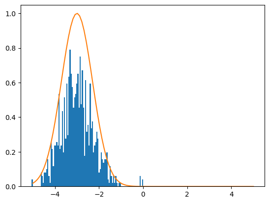

```python
def metropolis_hastings(target_distribution, initial_state, num_samples, proposal_distribution):
    samples = [initial_state]
    current_state = initial_state

    for _ in range(num_samples):
        proposed_state = proposal_distribution(current_state)
        acceptance_ratio = target_distribution(proposed_state) / target_distribution(current_state)
        acceptance_probability = min(1, acceptance_ratio)

        if np.random.uniform() < acceptance_probability:
            current_state = proposed_state

        samples.append(current_state)

    return samples

def target_distribution(x):
    return np.exp(-(x+3)**2)#np.exp(-np.cos(x)**2)

def proposal_distribution(x):
    return x + np.random.normal()#6*(np.random.rand()-0.5)#

N = 1000
samples = metropolis_hastings(target_distribution, 0, N, proposal_distribution)

plt.hist(samples, bins=100, density=True)
xi = np.linspace(-5, 5, 100)
plt.plot(xi, target_distribution(xi))
plt.show()
```

The main issue with this kind of approach is that it is in the discrete form and has to be converted back to the continuous-time form. As the system does not have a closed form discrete solution, this approach is not trivial, and it is again more challenging with the covariance matrix.

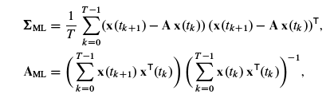

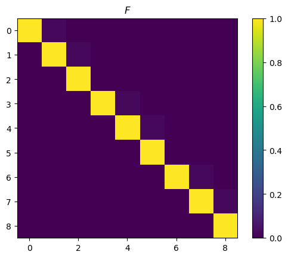

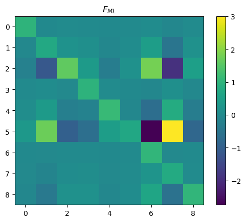

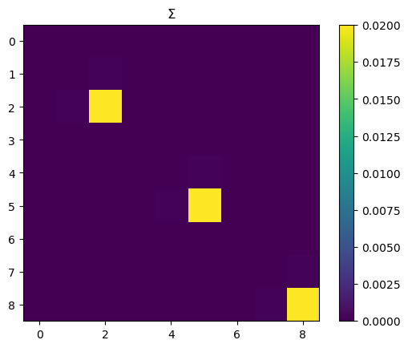

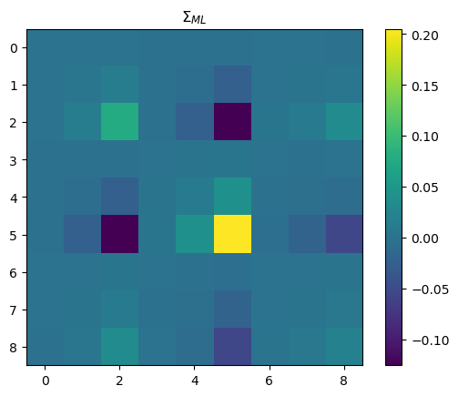

```python
xn = state[:,1:]
xp = state[:,:-1]
A_ml =  (xn @ xp.T) @ np.linalg.inv(xp @ xp.T + 1e-12 * np.eye(xp.shape[0]))

# print(-logm(A_ml)/dt, '\n\n',-logm(A_ml2)/dt, '\n\n',-logm(A_ml)/dt+logm(A_ml2)/dt)
# print(Ac, '\n\n', A_ml, '\n\n', np.linalg.norm(Ac-A_ml,'fro'), '\n\n')

# print(logm(Ac)/dt, '\n\n',logm(A_ml)/dt, '\n\n',np.linalg.norm(logm(A)/dt-logm(A_ml)/dt,'fro'), '\n\n')

plt.imshow(Ac);plt.colorbar();plt.title(r'$F$');plt.show()
plt.imshow(A_ml);plt.colorbar();plt.title(r'$F_{ML}$');plt.show()

S_1 = 1/state.shape[0] * (xn @ xn.T - A_ml @ xp @ xn.T)
SS_ml = xn - A_ml @ xp
SS_ml = SS_ml @ SS_ml.T / state.shape[0]

# print(S_1, '\n\n',SS_ml,'\n\n', np.linalg.norm(S_1-SS_ml,'fro'), '\n\n')
plt.imshow(S);plt.colorbar();plt.title(r'$\Sigma$');plt.show()
plt.imshow(S_1);plt.colorbar();plt.title(r'$\Sigma_{ML}$');plt.show()
# plt.imshow(SS_ml);plt.colorbar();plt.title(r'$\Sigma_{ML}$');plt.show()
```

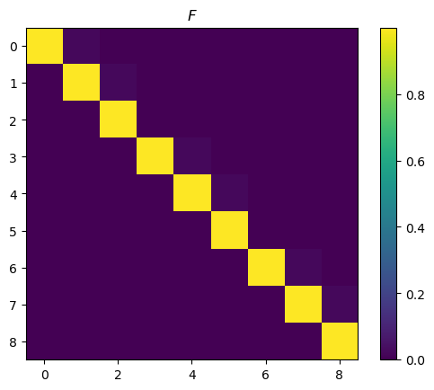

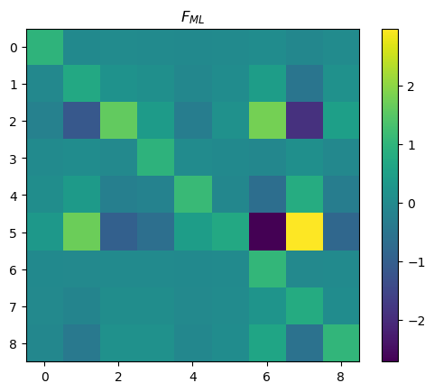

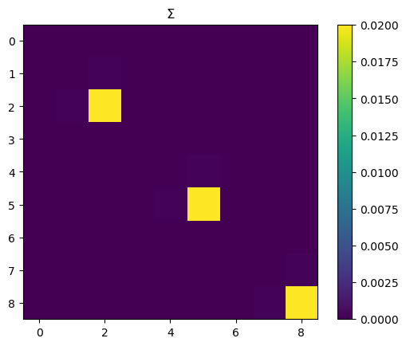

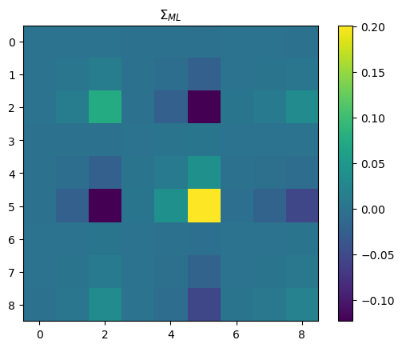

```python
xn = GP[:,1:]
xp = GP[:,:-1]
A_ml =  (xn @ xp.T) @ np.linalg.inv(xp @ xp.T+ 1e-12 * np.eye(xp.shape[0]))

# print(-logm(A_ml)/dt, '\n\n',-logm(A_ml2)/dt, '\n\n',-logm(A_ml)/dt+logm(A_ml2)/dt)
# print(A, '\n\n', A_ml, '\n\n', np.linalg.norm(A-A_ml,'fro'), '\n\n')

# print(logm(A)/dt, '\n\n',logm(A_ml)/dt, '\n\n',np.linalg.norm(logm(A)/dt-logm(A_ml)/dt,'fro'), '\n\n')

plt.imshow(A);plt.colorbar();plt.title(r'$F$');plt.show()
plt.imshow(A_ml);plt.colorbar();plt.title(r'$F_{ML}$');plt.show()

S_1 = 1/state.shape[0] * (xn @ xn.T - A_ml @ xp @ xn.T)
SS_ml = xn - A_ml @ xp
SS_ml = SS_ml @ SS_ml.T / state.shape[0]

# print(S_1, '\n\n',SS_ml,'\n\n', np.linalg.norm(S_1-SS_ml,'fro'), '\n\n')
plt.imshow(S);plt.colorbar();plt.title(r'$\Sigma$');plt.show()
plt.imshow(S_1);plt.colorbar();plt.title(r'$\Sigma_{ML}$');plt.show()
# plt.imshow(SS_ml);plt.colorbar();plt.title(r'$\Sigma_{ML}$');plt.show()
```